# RTong

hansu

2022-08-13

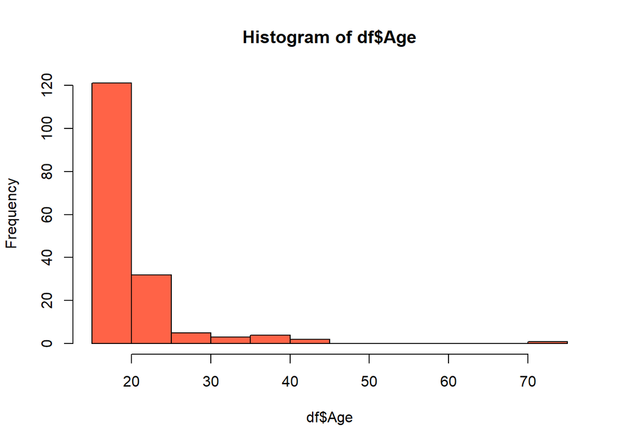

```r
hist(df$Age, col='tomato')   # 연령의 분포 살펴보기
```

## 평균에 대한 검정 - t검정

### 일표본 t검정(양측검정)

H0 : 학생들의 평균 나이가 23살이다.  
H1 : 학생들의 평균 나이가 23살이 아니다.

```r
t.test(df$Age, mu=23)
```

```
##
##  One Sample t-test
##
## data:  df$Age
## t = -5.4539, df = 167, p-value = 1.749e-07
## alternative hypothesis: true mean is not equal to 23
## 95 percent confidence interval:
##  19.50454 21.36261
## sample estimates:
## mean of x
##  20.43358
```

학생들의 평균 나이는 20.4세이고,  
검정통계량 t = -5.4539이고 p-value 1.749e-07이므로 유의수준 0.05에서 귀무가설을 기각한다.  
따라서 학생들의 평균 나이가 23살이 아니라고 할 수 있다.

### 일표본 t검정(단측검정)

H0 : 학생들의 평균 나이가 21살보다 작거나 같다.  
H1 : 학생들의 평균 나이가 21살보다 크다.

```r
t.test(df$Age, mu=21, alternative='greater')
```

```
##
##  One Sample t-test
##
## data:  df$Age
## t = -1.2037, df = 167, p-value = 0.8848
## alternative hypothesis: true mean is greater than 21
## 95 percent confidence interval:
##  19.65524      Inf
## sample estimates:
## mean of x
##  20.43358
```

학생들의 평균 나이는 20.4세이고,  
검정통계량 t = -1.2037이고 p-value=0.8848이므로 유의수준 0.05에서 귀무가설을 기각하지 못한다.  
따라서 학생들의 평균 나이가 21살보다 작거나 같다고 할 수 있다.

### 일표본 t검정(단측검정)

H0 : 학생들의 평균 나이가 21살보다 크거나 같다.  
H1 : 학생들의 평균 나이가 21살보다 작다.

```r
t.test(df$Age, mu=21, alternative='less')
```

```
##
##  One Sample t-test
##
## data:  df$Age
## t = -1.2037, df = 167, p-value = 0.1152
## alternative hypothesis: true mean is less than 21
## 95 percent confidence interval:
##      -Inf 21.21191
## sample estimates:
## mean of x
##  20.43358
```

### 독립표본 t검정

독립표본 t검정은 두 집단 간에 평균 차이가 있는지를 검정할 때 사용.

독립표본 t검정에서 ~ 앞에는 검정하고자 하는 종속변수 지정, ~ 뒤에는 집단을 나타내는 독립변수를 지정한다.  
또한 집단을 나타내는 독립변수는 팩터 형식이어야 한다.

H0 : 성별에 따라서 연령에 차이가 없다.  
H1 : 성별에 따라서 연령에 차이가 있다.

```r
t.test(Age~Sex, data=df)
```

```
##
##  Welch Two Sample t-test
##
## data:  Age by Sex
## t = -0.67983, df = 150.34, p-value = 0.4977
## alternative hypothesis: true difference in means between group Female and group Male is not equal to 0
## 95 percent confidence interval:
##  -2.503417  1.221726
## sample estimates:
## mean in group Female   mean in group Male
##             20.11315             20.75400
```

검정통계량 t = -0.67983, p-value 0.4977이므로 유의수준 0.05에서 귀무가설을 기각하지 못한다.  
따라서 성별에 따라 연령에 차이가 없다.

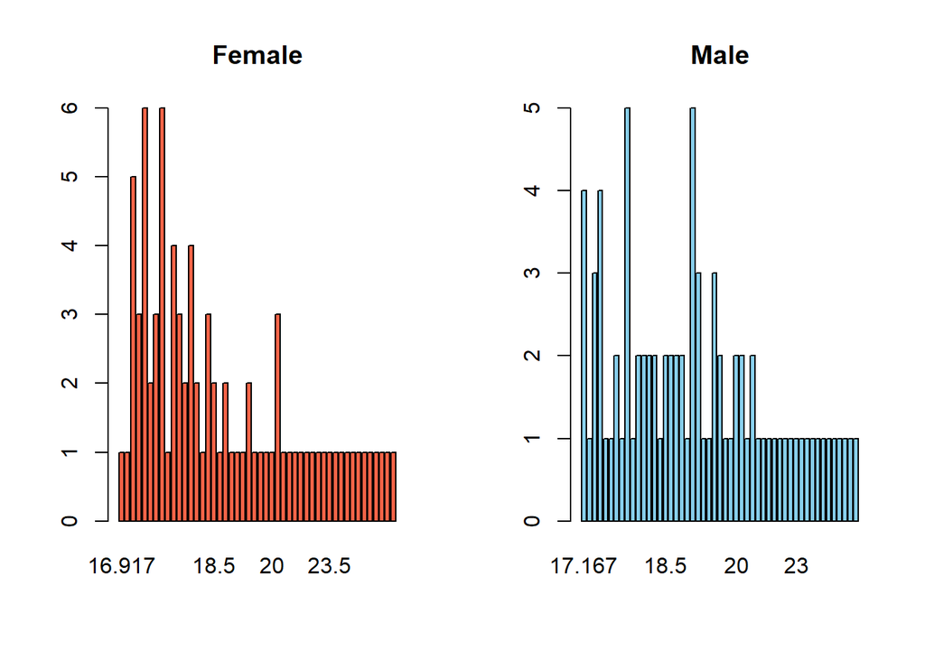

```r
par(mfrow=c(1, 2))
barplot(table(df[df$Sex=='Female', 'Age']), col='tomato', main='Female')
barplot(table(df[df$Sex=='Male', 'Age']), col='skyblue', main='Male')
```

```r
# 한 그래프 안에.. p.55처럼 그릴 수 있는 방법을 찾아보기
```

### 대응표본 t검정

같은 대상에게서 추출된 두 개의 데이터가 있을 때(ex : 사전-사후, 왼손-오른손) 사용

데이터셋 : sleep  
- 10명의 실험 대상자에게 두 종류의 수면제를 복용하게 한 후 수면제를 복용했을 때의 수면시간과 복용하지 않았을때의 수면시간의 차이를 기록.

H0 : 수면제에 따라 수면시간의 차이가 없다.  
H1 : 수면제에 따라 수면시간의 차이가 있다.

```r
df<-na.omit(sleep)
```

```r
str(df)
```

```
## 'data.frame':    20 obs. of  3 variables:
##  $ extra: num  0.7 -1.6 -0.2 -1.2 -0.1 3.4 3.7 0.8 0 2 ...
##  $ group: Factor w/ 2 levels "1","2": 1 1 1 1 1 1 1 1 1 1 ...
##  $ ID   : Factor w/ 10 levels "1","2","3","4",..: 1 2 3 4 5 6 7 8 9 10 ...
```

### 집단별 평균 알아보기

```r
mean(df[df$group==1, ]$extra)
```

```
## [1] 0.75
```

```r
mean(df[df$group==2, ]$extra)
```

```
## [1] 2.33
```

```r
t.test(extra~group, data=sleep, paired=T)
```

```
##
##  Paired t-test
##
## data:  extra by group
## t = -4.0621, df = 9, p-value = 0.002833
## alternative hypothesis: true mean difference is not equal to 0
## 95 percent confidence interval:
##  -2.4598858 -0.7001142
## sample estimates:
## mean difference
##           -1.58
```

집단1의 평균은 0.75, 집단2의 평균은 2.33으로 두 집단의 평균 차이는 -1.58이고, 검정통계량 t = -4.0621이고 p-value=0.002833이므로 유의수준 0.05에서 귀무가설을 기각한다.  
따라서 수면제에 따라 수면시간에 차이가 있다고 할 수 있다.

### 와이드 포맷의 형태

하나의 행에 두 수면제에 대한 수면시간이 쌍을 이룬 채 나란히 기록되어 있는 경우에는 포뮬러(~)를 이용하여 인수를 지정하지 못함.

```r
library(tidyr)  # spread 함수가 tidyr 안에 있음
sleep.wide<-spread(sleep, key=group, value=extra)
```

```r
sleep.wide
```

```
##    ID    1    2
## 1   1  0.7  1.9
## 2   2 -1.6  0.8
## 3   3 -0.2  1.1
## 4   4 -1.2  0.1
## 5   5 -0.1 -0.1
## 6   6  3.4  4.4
## 7   7  3.7  5.5
## 8   8  0.8  1.6
## 9   9  0.0  4.6
## 10 10  2.0  3.4
```

이런 형태가 와이드 포맷 형태. 처음에 본 sleep 데이터는 롱 포맷 형태.

```r
t.test(sleep.wide$`1`, sleep.wide$`2`, paired=T)
```

```
##
##  Paired t-test
##
## data:  sleep.wide$`1` and sleep.wide$`2`
## t = -4.0621, df = 9, p-value = 0.002833
## alternative hypothesis: true mean difference is not equal to 0
## 95 percent confidence interval:
##  -2.4598858 -0.7001142
## sample estimates:
## mean difference
##           -1.58
```

## 분산분석

- 검정 통계량 : F = 집단 간 분산, 집단 내 분산 비

### 분산분석의 기본가정

- 정규성 : 종속변수는 정규분포를 따른다.

```r
df <- na.omit(survey)
library(car)
```

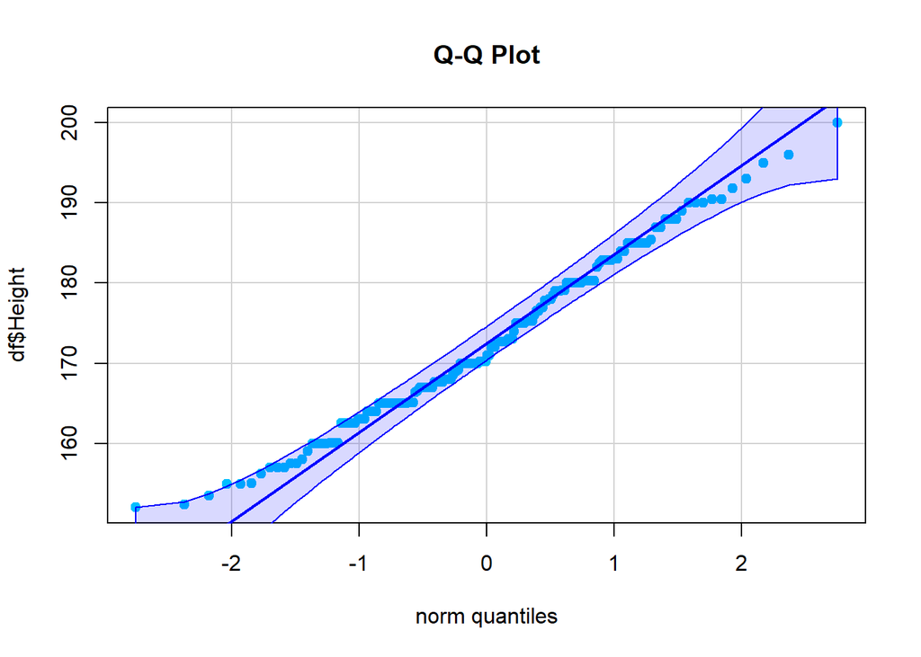

```r
qqPlot(df$Height, pch = 19, col='deepskyblue', id = F,
       main = 'Q-Q Plot')
```

```r
shapiro.test(df$Height)
```

```
##
##  Shapiro-Wilk normality test
##
## data:  df$Height
## W = 0.98521, p-value = 0.07218
```

- 등분산성 : 각 집단의 분포는 모두 동일한 분산을 갖는다.

```r
leveneTest(Height ~ Clap, data = df)
```

```
## Levene's Test for Homogeneity of Variance (center = median)
##        Df F value Pr(>F)
## group   2  0.1102 0.8957
##       165
```

```r
bartlett.test(Height ~ Clap, data = df)
```

```
##
##  Bartlett test of homogeneity of variances
##
## data:  Height by Clap
## Bartlett's K-squared = 0.83456, df = 2, p-value = 0.6588
```

- 등분산 미만족 시

```r
oneway.test(Height ~ Clap, data = df)
```

```
##
##  One-way analysis of means (not assuming equal variances)
##
## data:  Height and Clap
## F = 0.2729, num df = 2.000, denom df = 53.917, p-value = 0.7622
```

### 일원분산분석

- 분석전 범주별 분포 확인

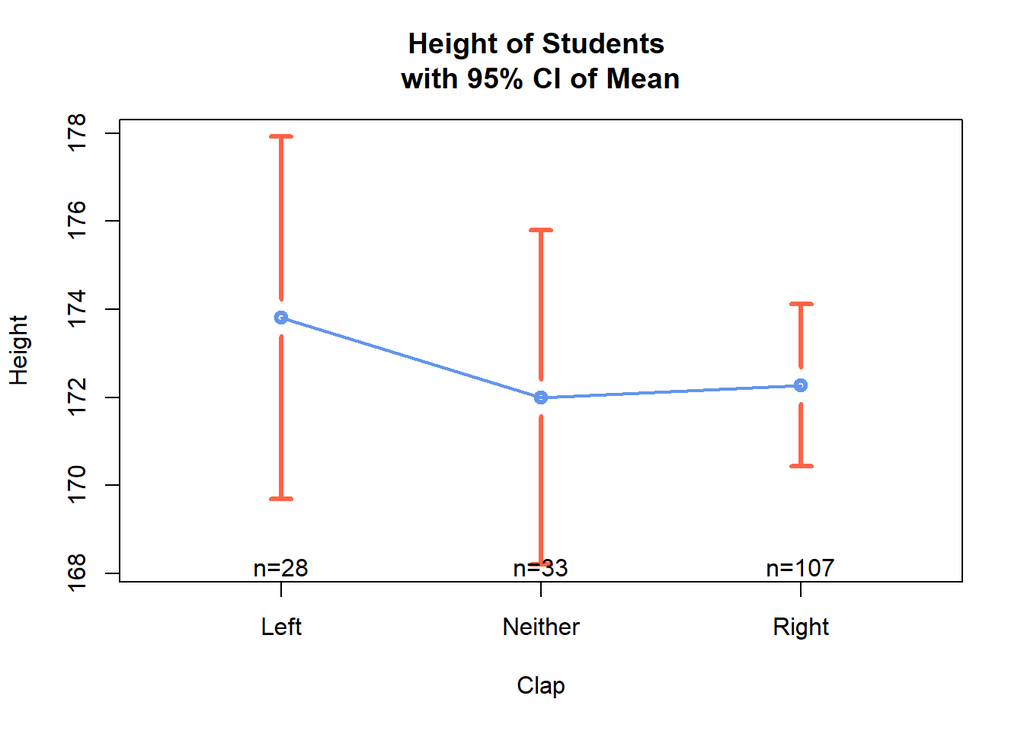

```r
library(gplots)
plotmeans(Height~Clap ,data = df,
          barcol='tomato', barwidth=3, col='cornflowerblue', lwd=2,
          main='Height of Students \nwith 95% CI of Mean')
```

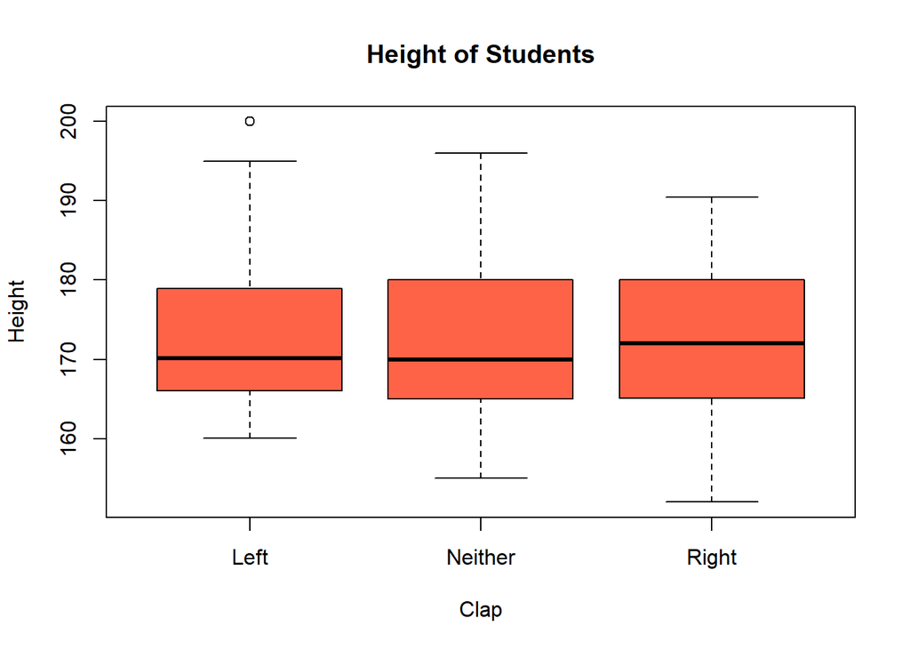

```r
boxplot(Height~Clap ,data = df, col = 'tomato',
        main ='Height of Students')
```

- anova 생성

```r
st.aov<-aov(Height~Clap ,data = df,)
st.aov
```

```
## Call:
##    aov(formula = Height ~ Clap, data = df)
##
## Terms:
##                      Clap Residuals
## Sum of Squares     61.522 16503.623
## Deg. of Freedom         2       165
##
## Residual standard error: 10.0011
## Estimated effects may be unbalanced
```

```r
summary(st.aov)
```

```
##              Df Sum Sq Mean Sq F value Pr(>F)
## Clap          2     62   30.76   0.308  0.736
## Residuals   165  16504  100.02
```

##### 사후분석

- 다중비교 각 집단평균과 전체평균의 차이

```r
model.tables(st.aov, type = 'effects')
```

```
## Tables of effects
##
##  Clap
##       Left Neither    Right
##      1.332 -0.4787  -0.2008
## rep 28.000 33.0000 107.0000
```

- Tukey HSD 검정

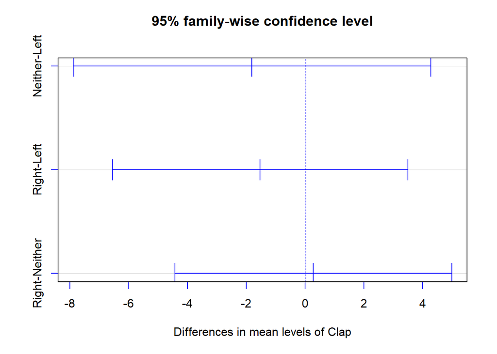

```r
st.compare <- TukeyHSD(st.aov)
plot(st.compare, col = 'blue')
```

- 범주별 그룹화

```r
library(multcomp)
```

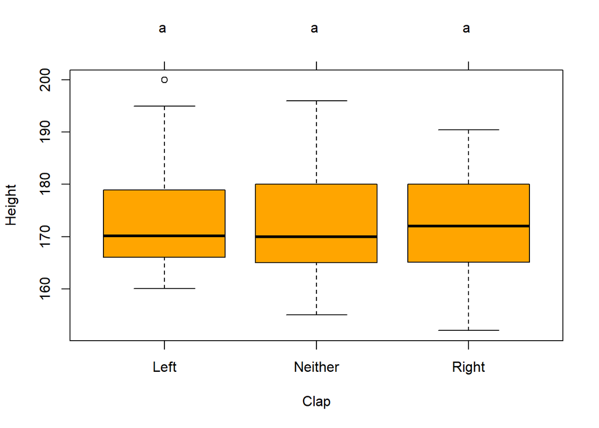

```r
tuk.hsd <- glht(model = st.aov, linfct = mcp(Clap = 'Tukey'))
plot(cld(tuk.hsd, level = 0.05), col = 'orange')
```

- 정규성 미만족 시 이상치 탐색

```r
outlierTest(st.aov)
```

```
## No Studentized residuals with Bonferroni p < 0.05
## Largest |rstudent|:
##    rstudent unadjusted p-value Bonferroni p
## 51 2.718122          0.0072713           NA
```

### 이원분산분석

```r
st.aov <- aov(Height ~ Sex * Clap, data = df)
summary(st.aov)
```

```
##              Df Sum Sq Mean Sq F value Pr(>F)
## Sex           1   7938    7938 153.548 <2e-16 ***
## Clap          2    149      75   1.446  0.239
## Sex:Clap      2    104      52   1.002  0.370
## Residuals   162   8375      52
## ---
## Signif. codes:  0 '***' 0.001 '**' 0.01 '*' 0.05 '.' 0.1 ' ' 1
```

##### 사후분석

- 다중비교 각 집단평균과 전체평균의 차이

```r
model.tables(st.aov, type = 'effects')
```

```
## Tables of effects
##
##  Sex
##     Female   Male
##     -6.874  6.874
## rep 84.000 84.000
##
##  Clap
##       Left Neither    Right
##      1.823  0.5627  -0.6505
## rep 28.000 33.0000 107.0000
##
##  Sex:Clap
##         Clap
## Sex      Left  Neither Right
##   Female -0.68 -1.09    0.62
##   rep    15.00 19.00   50.00
##   Male    0.79  1.47   -0.54
##   rep    13.00 14.00   57.00
```

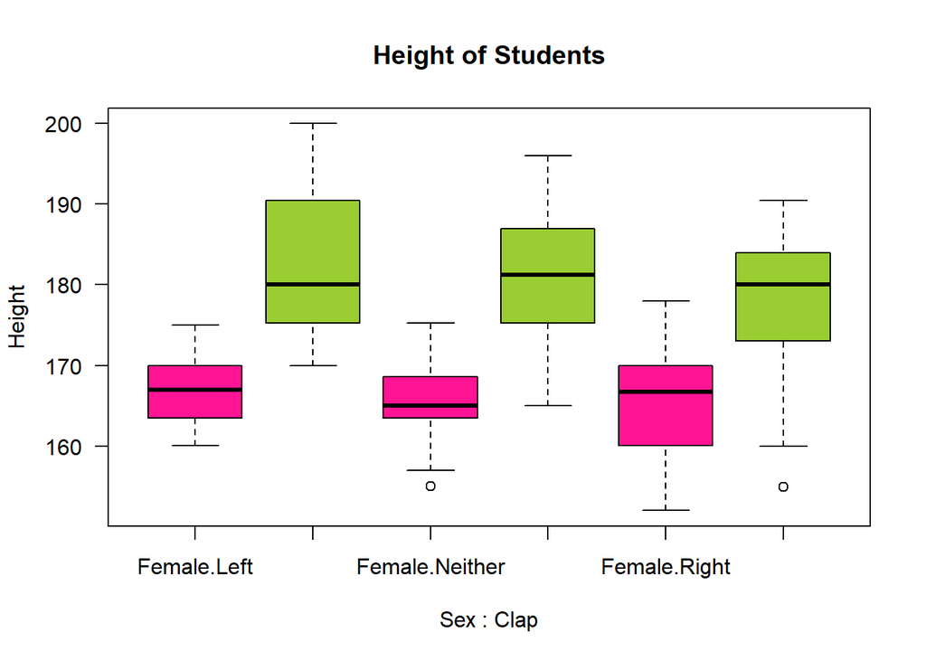

```r
boxplot(Height ~ Sex * Clap, data = df,
        col = c('deeppink', 'yellowgreen'), las=1,
        main ='Height of Students')
```

- 상호작용도표

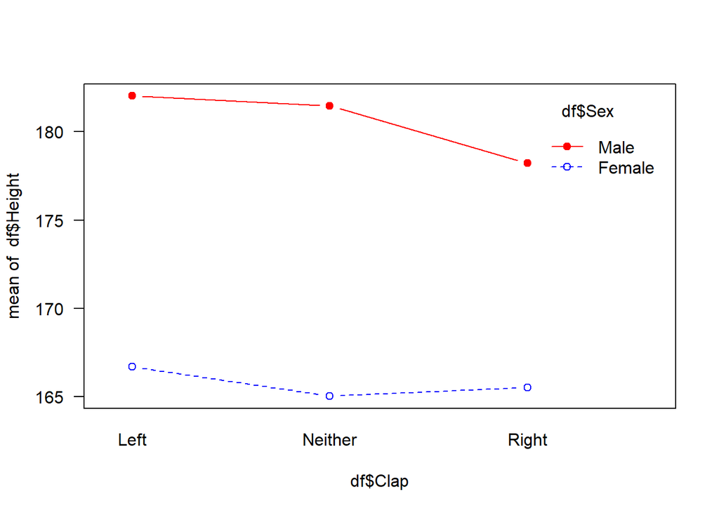

```r
interaction.plot(x.factor = df$Clap, trace.factor = df$Sex,
                 response = df$Height, las = 1, type = 'b', pch = c(1,19),
                 col = c('blue', 'red'))
```

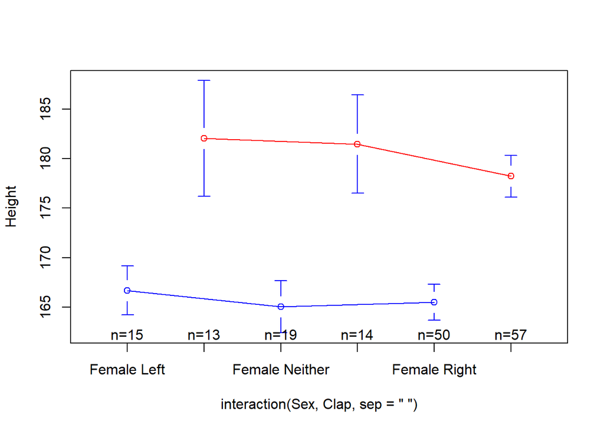

```r
library(gplots)
plotmeans(Height ~ interaction(Sex, Clap, sep = ' '), data = df,
          connect = list(c(1,3,5), c(2,4,6)),
          col = c('blue', 'red'))
```

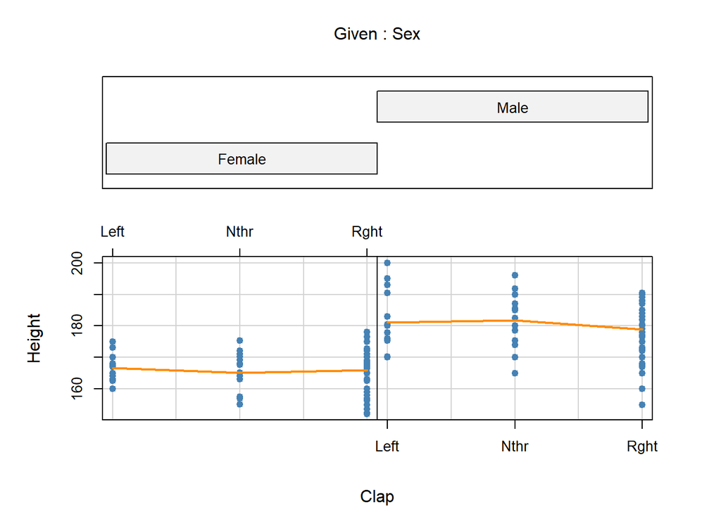

```r
coplot(Height ~ Clap | Sex, data = df,
       col = 'steelblue', pch = 19,
       panel = panel.smooth, lwd = 2, col.smooth = 'darkorange')
```

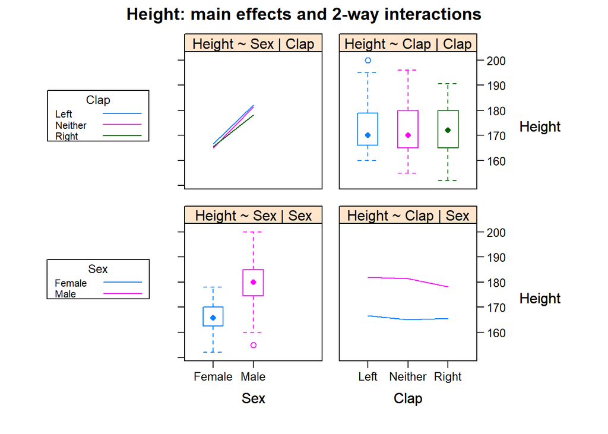

```r
library(HH)
interaction2wt(Height ~ Sex * Clap, data = df)
```

## Chi-Squred Test

- 범주형 변수 간의 관련성 검정
- 교차표 (사실 각 셀이 5보다 커야 좋음)

```r
library(gmodels)
ct<-CrossTable(x=df$Sex, y=df$Smoke)
```

```
##
##
##    Cell Contents
## |-------------------------|
## |                       N |
## | Chi-square contribution |
## |           N / Row Total |
## |           N / Col Total |
## |         N / Table Total |
## |-------------------------|
##
##
## Total Observations in Table:  168
##
##
##              | df$Smoke
##       df$Sex |     Heavy |     Never |     Occas |     Regul | Row Total |
## -------------|-----------|-----------|-----------|-----------|-----------|
##       Female |         4 |        70 |         7 |         3 |        84 |
##              |     0.071 |     0.134 |     0.038 |     2.286 |           |
##              |     0.048 |     0.833 |     0.083 |     0.036 |     0.500 |
##              |     0.571 |     0.522 |     0.538 |     0.214 |           |
##              |     0.024 |     0.417 |     0.042 |     0.018 |           |
## -------------|-----------|-----------|-----------|-----------|-----------|
##         Male |         3 |        64 |         6 |        11 |        84 |
##              |     0.071 |     0.134 |     0.038 |     2.286 |           |
##              |     0.036 |     0.762 |     0.071 |     0.131 |     0.500 |
##              |     0.429 |     0.478 |     0.462 |     0.786 |           |
##              |     0.018 |     0.381 |     0.036 |     0.065 |           |
## -------------|-----------|-----------|-----------|-----------|-----------|
## Column Total |         7 |       134 |        13 |        14 |       168 |
##              |     0.042 |     0.798 |     0.077 |     0.083 |           |
## -------------|-----------|-----------|-----------|-----------|-----------|
##
##
```

```r
ct <- ct$t
ct
```

```
##         y
## x        Heavy Never Occas Regul
##   Female     4    70     7     3
##   Male       3    64     6    11
```

- 검정통계량 : ( 실제 빈도수 - 기대 빈도수 )^2 / 기대 빈도수 총합

### 독립성검정

- 두 범주형 변수가 서로 독립인지 검정

```r
chisq.test(ct)
```

```
##
##  Pearson's Chi-squared test
##
## data:  ct
## X-squared = 5.0599, df = 3, p-value = 0.1675
```

```r
# 교차표 없이 분석
with(df, chisq.test(Smoke, Sex))
```

```
##
##  Pearson's Chi-squared test
##
## data:  Smoke and Sex
## X-squared = 5.0599, df = 3, p-value = 0.1675
```

```r
library(vcd)
assocstats(ct)
```

```
##                     X^2 df P(> X^2)
## Likelihood Ratio 5.3490  3  0.14796
## Pearson          5.0599  3  0.16747
##
## Phi-Coefficient   : NA
## Contingency Coeff.: 0.171
## Cramer's V        : 0.174
```

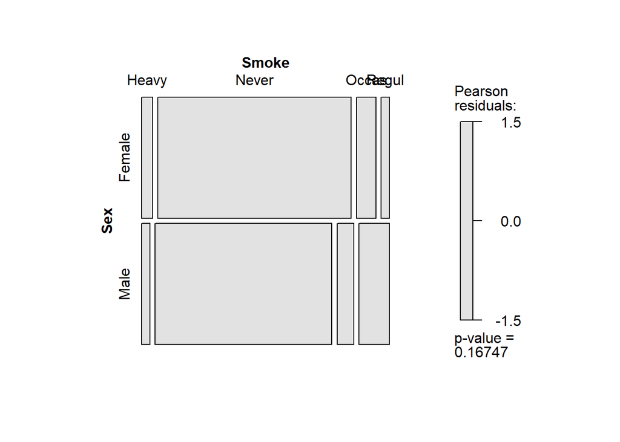

```r
mosaic(~Sex + Smoke , data = df, shade = T, legend = T)
```

### 적합성검정

- 하나의 범주형 변수내 비율 분포에 대한 검정

```r
# 귀무 : df 자료 내 흡연 비율이 같다
chisq.test(table(df$Smoke))
```

```
##
##  Chi-squared test for given probabilities
##
## data:  table(df$Smoke)
## X-squared = 269.38, df = 3, p-value < 2.2e-16
```

```r
# 귀무 : df 자료 내 남녀 비율 3:2 이다
chisq.test(table(df$Sex), p = c(0.4,0.6))
```

```
##
##  Chi-squared test for given probabilities
##
## data:  table(df$Sex)
## X-squared = 7, df = 1, p-value = 0.008151
```

## 회귀분석

```r
df<-airquality
summary(df)
```

```
##      Ozone           Solar.R           Wind             Temp
##  Min.   :  1.00   Min.   :  7.0   Min.   : 1.700   Min.   :56.00
##  1st Qu.: 18.00   1st Qu.:115.8   1st Qu.: 7.400   1st Qu.:72.00
##  Median : 31.50   Median :205.0   Median : 9.700   Median :79.00
##  Mean   : 42.13   Mean   :185.9   Mean   : 9.958   Mean   :77.88
##  3rd Qu.: 63.25   3rd Qu.:258.8   3rd Qu.:11.500   3rd Qu.:85.00
##  Max.   :168.00   Max.   :334.0   Max.   :20.700   Max.   :97.00
##  NA's   :37       NA's   :7
##      Month            Day
##  Min.   :5.000   Min.   : 1.0
##  1st Qu.:6.000   1st Qu.: 8.0
##  Median :7.000   Median :16.0
##  Mean   :6.993   Mean   :15.8
##  3rd Qu.:8.000   3rd Qu.:23.0
##  Max.   :9.000   Max.   :31.0
##
```

- 각 열의 요약 통계량과 NA의 수를 확인한 결과
  - Ozone은 37개, Solar.R은 7개 있으므로 NA값을 모두 삭제

```r
df<-na.omit(airquality)
str(df) # 모두 수치형데이터(연속형)
```

```
## 'data.frame':    111 obs. of  6 variables:
##  $ Ozone  : int  41 36 12 18 23 19 8 16 11 14 ...
##  $ Solar.R: int  190 118 149 313 299 99 19 256 290 274 ...
##  $ Wind   : num  7.4 8 12.6 11.5 8.6 13.8 20.1 9.7 9.2 10.9 ...
##  $ Temp   : int  67 72 74 62 65 59 61 69 66 68 ...
##  $ Month  : int  5 5 5 5 5 5 5 5 5 5 ...
##  $ Day    : int  1 2 3 4 7 8 9 12 13 14 ...
##  - attr(*, "na.action")= 'omit' Named int [1:42] 5 6 10 11 25 26 27 32 33 34 ...
##   ..- attr(*, "names")= chr [1:42] "5" "6" "10" "11" ...
```

```r
class(df) # 데프
```

```
## [1] "data.frame"
```

```r
summary(df) # NA값 사라진지 확인
```

```
##      Ozone          Solar.R           Wind            Temp
##  Min.   :  1.0   Min.   :  7.0   Min.   : 2.30   Min.   :57.00
##  1st Qu.: 18.0   1st Qu.:113.5   1st Qu.: 7.40   1st Qu.:71.00
##  Median : 31.0   Median :207.0   Median : 9.70   Median :79.00
##  Mean   : 42.1   Mean   :184.8   Mean   : 9.94   Mean   :77.79
##  3rd Qu.: 62.0   3rd Qu.:255.5   3rd Qu.:11.50   3rd Qu.:84.50
##  Max.   :168.0   Max.   :334.0   Max.   :20.70   Max.   :97.00
##      Month            Day
##  Min.   :5.000   Min.   : 1.00
##  1st Qu.:6.000   1st Qu.: 9.00
##  Median :7.000   Median :16.00
##  Mean   :7.216   Mean   :15.95
##  3rd Qu.:9.000   3rd Qu.:22.50
##  Max.   :9.000   Max.   :31.00
```

- str()로 모든 열들이 수치형(연속형)인것을 확인
- class()로 데이터 프레임
- summary()로 NA 행이 삭제되었는지 확인

```r
library(psych)
corr.test(df)
```

```
## Call:corr.test(x = df)
## Correlation matrix
##         Ozone Solar.R  Wind  Temp Month   Day
## Ozone    1.00    0.35 -0.61  0.70  0.14 -0.01
## Solar.R  0.35    1.00 -0.13  0.29 -0.07 -0.06
## Wind    -0.61   -0.13  1.00 -0.50 -0.19  0.05
## Temp     0.70    0.29 -0.50  1.00  0.40 -0.10
## Month    0.14   -0.07 -0.19  0.40  1.00 -0.01
## Day     -0.01   -0.06  0.05 -0.10 -0.01  1.00
## Sample Size
## [1] 111
## Probability values (Entries above the diagonal are adjusted for multiple tests.)
##         Ozone Solar.R Wind Temp Month Day
## Ozone    0.00    0.00 0.00 0.00  1.00   1
## Solar.R  0.00    0.00 1.00 0.02  1.00   1
## Wind     0.00    0.18 0.00 0.00  0.37   1
## Temp     0.00    0.00 0.00 0.00  0.00   1
## Month    0.13    0.44 0.04 0.00  0.00   1
## Day      0.96    0.55 0.60 0.31  0.93   0
##
##  To see confidence intervals of the correlations, print with the short=FALSE option
```

- 종속변수Ozone열과
- Ozone열과 Wind열과 상관계수가 -0.6
- Ozone열과 Temp열과 상관계수가 0.7
- Probability values는 유의 수준처럼 0.05보다 작으면 *통계적*으로 유의하다고 할 수 있다.

## Wind와 Ozone 상관계수

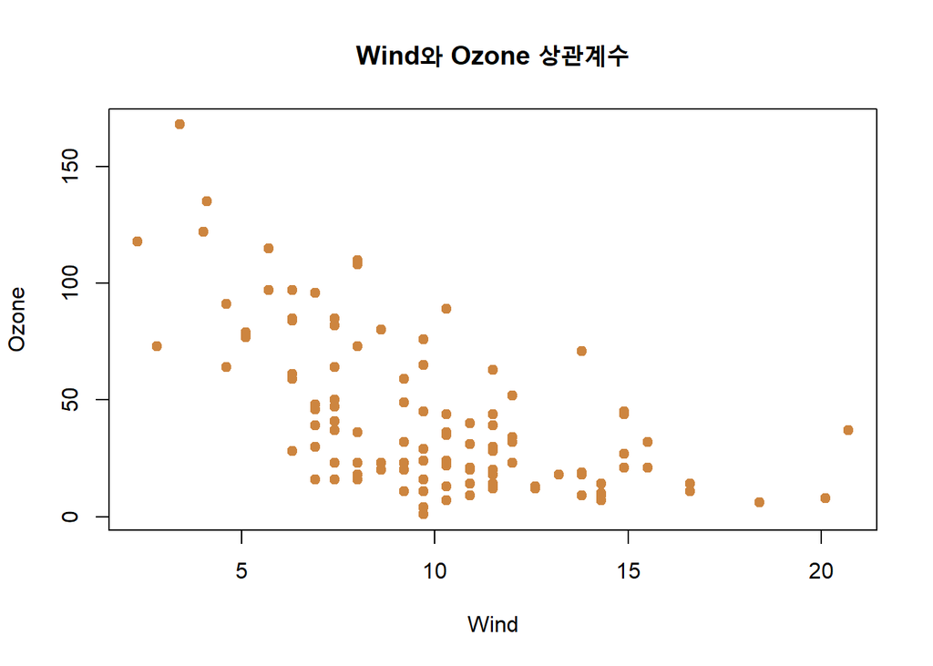

```r
plot(df$Wind,df$Ozone,main='Wind와 Ozone 상관계수',
     xlab='Wind',ylab='Ozone',col='peru',pch=19)
```

- 강한 음의 상관이 보임

## Temp와 Ozone 상관계수

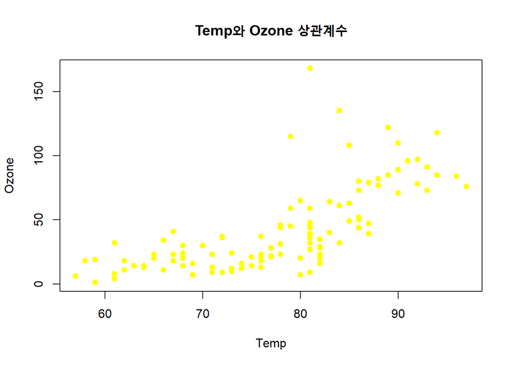

```r
plot(df$Temp,df$Ozone,main='Temp와 Ozone 상관계수',
     xlab='Temp',ylab='Ozone',col='yellow1',pch=19)
```

- 강한 양의 상관이 보임

### 단순회귀분석

#### 상관계수가 가장 높았던 Ozone와 Temp

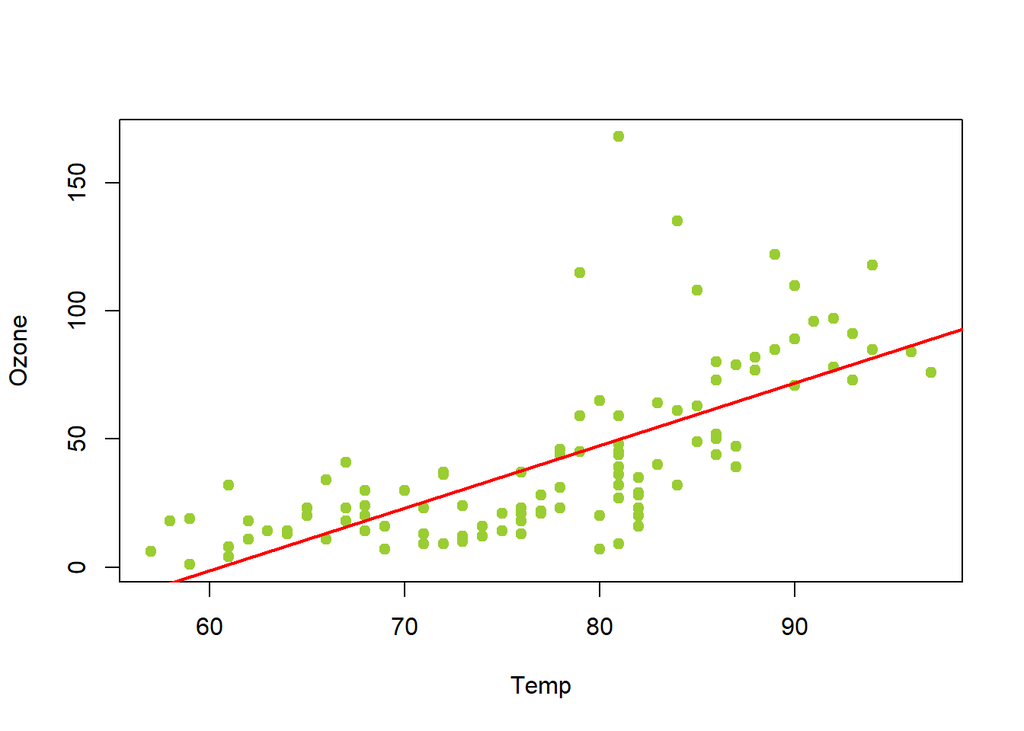

```r
model<-lm(Ozone~Temp,data=df)
plot(Ozone~Temp,data=df,col='yellowgreen',pch=19)
abline(model,col='red',lwd=2)
```

### 다중회귀분석

#### 변수선택법(전진선택법)

```r
model_up<-lm(Ozone~.,data=df)
model_lo<-lm(Ozone~1,data=df)
model<-lm(Temp~.,data=df)
step(model_lo,scope=list(upper=model_up),direction = 'forward')
```

```
## Start:  AIC=779.07
## Ozone ~ 1
##
##           Df Sum of Sq    RSS    AIC
## + Temp     1     59434  62367 706.77
## + Wind     1     45694  76108 728.87
## + Solar.R  1     14780 107022 766.71
## + Month    1      2487 119315 778.78
## <none>                 121802 779.07
## + Day      1         3 121799 781.07
##
## Step:  AIC=706.77
## Ozone ~ Temp
##
##           Df Sum of Sq   RSS    AIC
## + Wind     1   11378.5 50989 686.41
## + Month    1    2824.7 59543 703.63
## + Solar.R  1    2723.1 59644 703.82
## <none>                 62367 706.77
## + Day      1     476.5 61891 707.92
##
## Step:  AIC=686.41
## Ozone ~ Temp + Wind
##
##           Df Sum of Sq   RSS    AIC
## + Solar.R  1   2986.17 48003 681.71
## + Month    1   2734.79 48254 682.29
## <none>                 50989 686.41
## + Day      1    486.59 50502 687.35
##
## Step:  AIC=681.71
## Ozone ~ Temp + Wind + Solar.R
##
##         Df Sum of Sq   RSS    AIC
## + Month  1   1701.18 46302 679.71
## <none>               48003 681.71
## + Day    1    564.53 47438 682.40
##
## Step:  AIC=679.71
## Ozone ~ Temp + Wind + Solar.R + Month
##
##        Df Sum of Sq   RSS    AIC
## <none>              46302 679.71
## + Day   1    618.68 45683 680.21
```

```
##
## Call:
## lm(formula = Ozone ~ Temp + Wind + Solar.R + Month, data = df)
##
## Coefficients:
## (Intercept)         Temp         Wind      Solar.R        Month
##    -58.0538       1.8709      -3.3165       0.0496      -2.9916
```

#### 변수선택법으로 선택된 변수의 회귀분석

```r
model_final<-lm(Ozone ~ Temp + Wind + Solar.R + Month,data=df)
summary(model_final)
```

```
##
## Call:
## lm(formula = Ozone ~ Temp + Wind + Solar.R + Month, data = df)
##
## Residuals:
##     Min      1Q  Median      3Q     Max
## -35.870 -13.968  -2.671   9.553  97.918
##
## Coefficients:
##              Estimate Std. Error t value Pr(>|t|)
## (Intercept) -58.05384   22.97114  -2.527   0.0130 *
## Temp          1.87087    0.27363   6.837 5.34e-10 ***
## Wind         -3.31651    0.64579  -5.136 1.29e-06 ***
## Solar.R       0.04960    0.02346   2.114   0.0368 *
## Month        -2.99163    1.51592  -1.973   0.0510 .
## ---
## Signif. codes:  0 '***' 0.001 '**' 0.01 '*' 0.05 '.' 0.1 ' ' 1
##
## Residual standard error: 20.9 on 106 degrees of freedom
## Multiple R-squared:  0.6199, Adjusted R-squared:  0.6055
## F-statistic: 43.21 on 4 and 106 DF,  p-value: < 2.2e-16
```

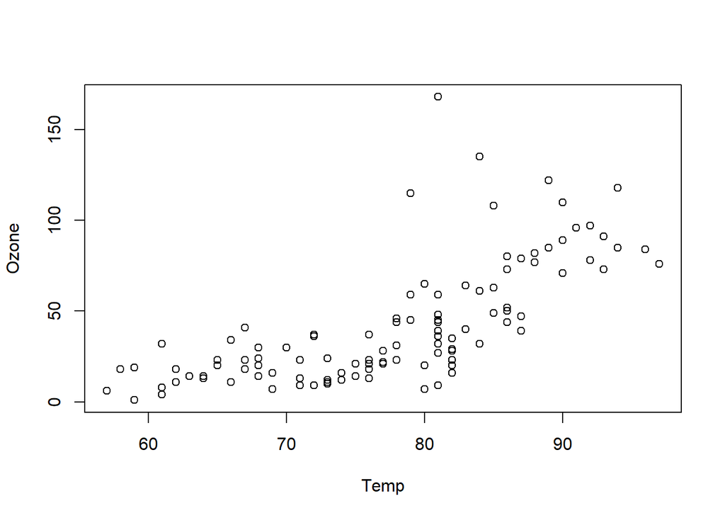

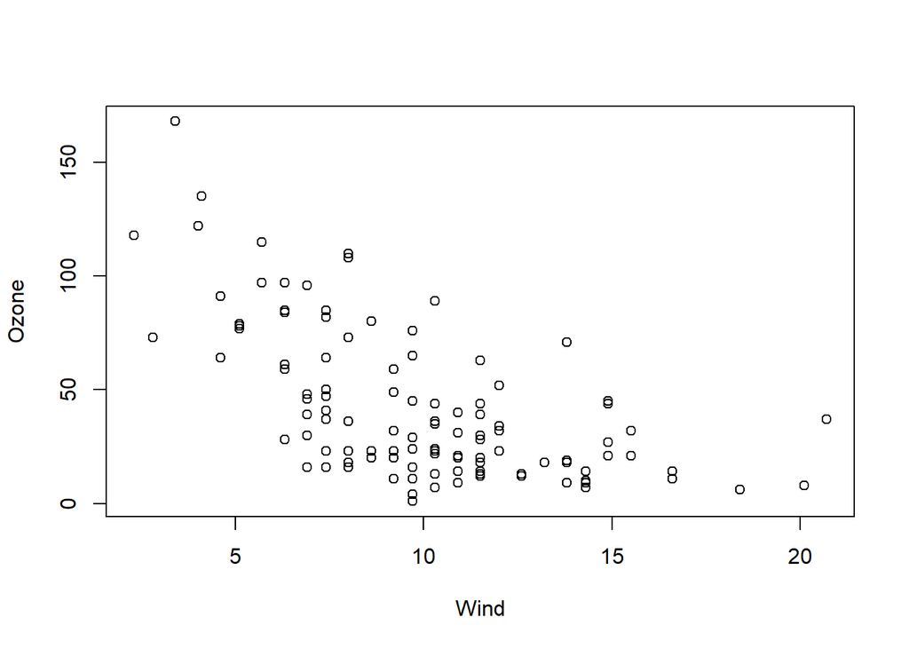

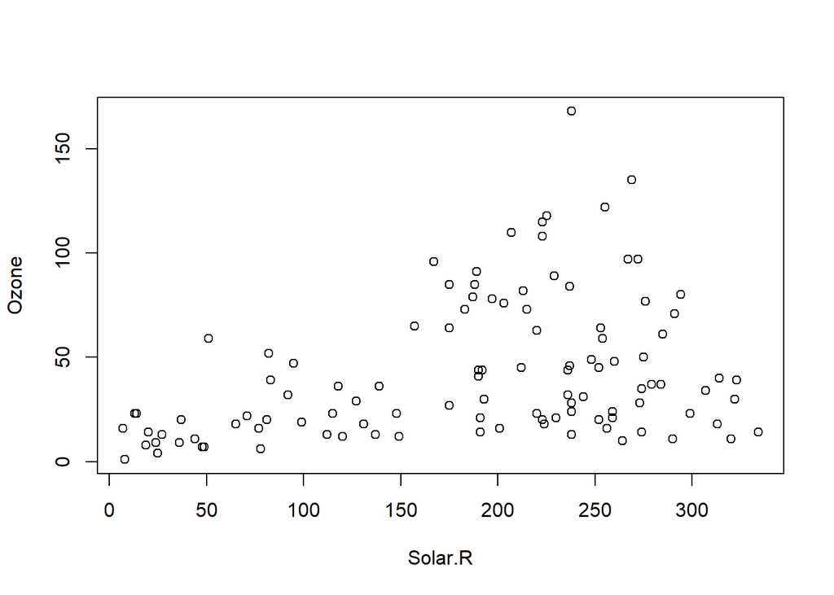

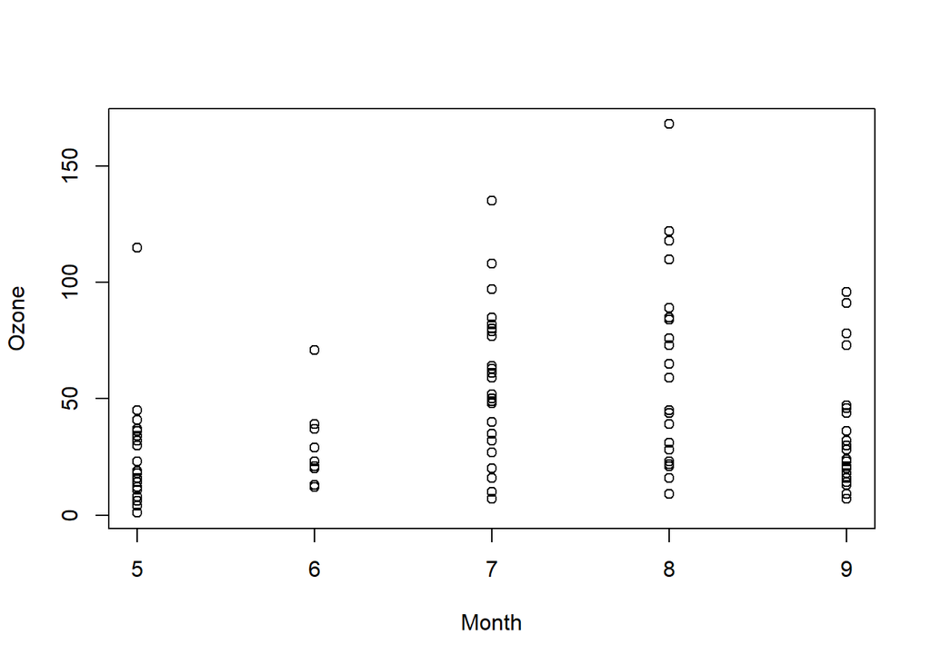

```r
plot(Ozone ~ Temp + Wind + Solar.R + Month,data=df)
```

### 다항 회귀분석

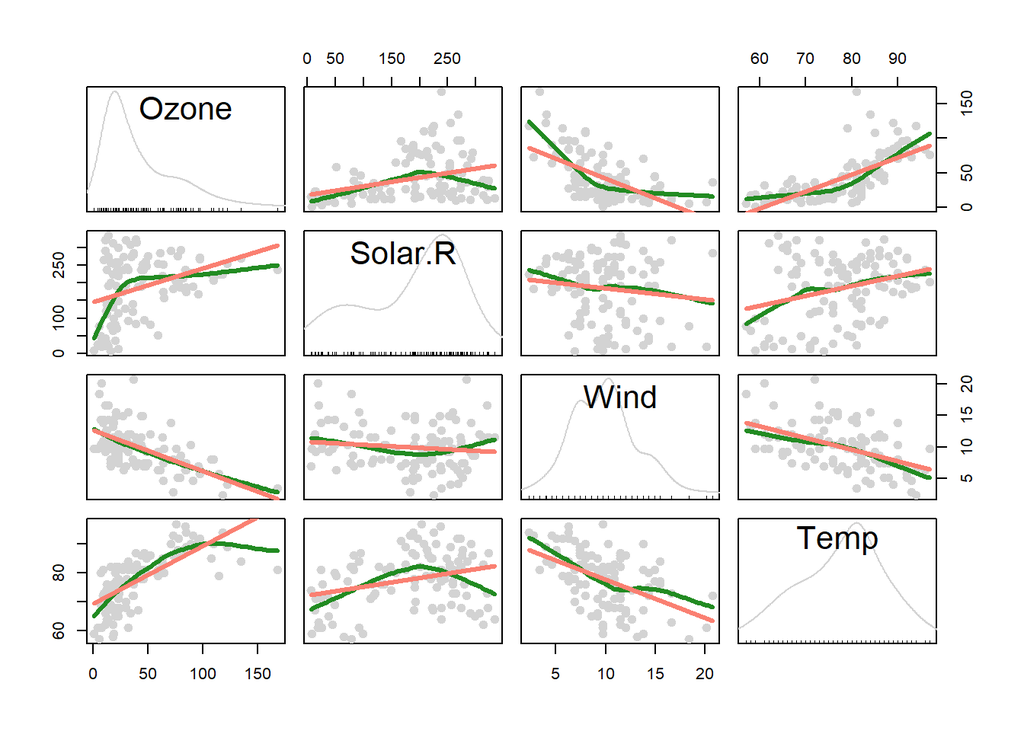

```r
library(car)
scatterplotMatrix(df[,1:4], pch = 19,col = 'lightgray', cex = 1.2,
                  regLine = list(method = lm, lty = 1,
                                 lwd = 3,col = 'salmon'),
                  smooth=list(smoother = loessLine, spread =F,
                              lty.smooth = 1, lwd.smooth = 3,
                              col.smooth = 'forestgreen'))
```

- Ozone, Wind 간의 이차곡선 처럼 보이는 분포 확인

```r
model <- lm(Ozone~ I(Wind^2)+Wind, data = df)
summary(model)
```

```
##
## Call:
## lm(formula = Ozone ~ I(Wind^2) + Wind, data = df)
##
## Residuals:
##     Min      1Q  Median      3Q     Max
## -44.573 -14.450  -5.327  12.346  61.440
##
## Coefficients:
##             Estimate Std. Error t value Pr(>|t|)
## (Intercept) 166.7663    14.3438  11.626  < 2e-16 ***
## I(Wind^2)     0.6621     0.1241   5.335 5.31e-07 ***
## Wind        -19.9586     2.7413  -7.281 5.66e-11 ***
## ---
## Signif. codes:  0 '***' 0.001 '**' 0.01 '*' 0.05 '.' 0.1 ' ' 1
##
## Residual standard error: 23.62 on 108 degrees of freedom
## Multiple R-squared:  0.5055, Adjusted R-squared:  0.4963
## F-statistic:  55.2 on 2 and 108 DF,  p-value: < 2.2e-16
```

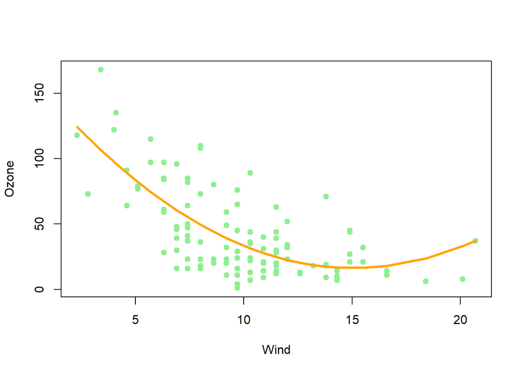

```r
plot(Ozone~ Wind, data = df, pch = 19, col = 'lightgreen')

library(dplyr)
with(df, lines(arrange(data.frame(df$Wind, fitted(model)),
                       df$Wind),
               lty = 1, lwd = 3, col = 'orange'
               ))
```

## 회귀모형의 설명력 판단

#### 회귀모형의 기본 전제 조건

- 선형성 : 독립 변수와 종속변수 간의 선형관계가 존재 Residuals vs Fitted
- 정규성 : 종속변수는 정규분포를 따른다 qqplot(), shapiro.test()
- 등분산성 : 종속변수 값들의 분포는 모두 동일한 분산을 가진다 (잔차의 독립성) Scale-Location Plot
- 독립성 : 모든 독립변수의 관측값들은 서로 독립 car::vif()

### 결정계수 R-squred

- 변수들과 종속변수 간에 선형관계의 정도를 설명
- 다중/다항 회귀에서는 adjusted R^2를 사용

```r
summary(model)
```

```
##
## Call:
## lm(formula = Ozone ~ I(Wind^2) + Wind, data = df)
##
## Residuals:
##     Min      1Q  Median      3Q     Max
## -44.573 -14.450  -5.327  12.346  61.440
##
## Coefficients:
##             Estimate Std. Error t value Pr(>|t|)
## (Intercept) 166.7663    14.3438  11.626  < 2e-16 ***
## I(Wind^2)     0.6621     0.1241   5.335 5.31e-07 ***
## Wind        -19.9586     2.7413  -7.281 5.66e-11 ***
## ---
## Signif. codes:  0 '***' 0.001 '**' 0.01 '*' 0.05 '.' 0.1 ' ' 1
##
## Residual standard error: 23.62 on 108 degrees of freedom
## Multiple R-squared:  0.5055, Adjusted R-squared:  0.4963
## F-statistic:  55.2 on 2 and 108 DF,  p-value: < 2.2e-16
```

### AIC

- 모델의 적합도와 파라미터 수를 고려, 적을 수록 적합

```r
AIC(model)
```

```
## [1] 1021.91
```

## 일반화 회귀모형 Generalized Linear Model

- 정규분포를 따르지 않는 결과변수에 대한 회귀모델
- 최대 우도법(MLE) 이용 회귀 계수 추정

### 이항 로지스틱 회귀모형

- 결과변수가 이분형 범주일 때 특정 사건이 발생할 확률 추정
- link func : ln(p / 1-p) = a + b1 X x1 + b2 X x2…
- odds = p / 1-p

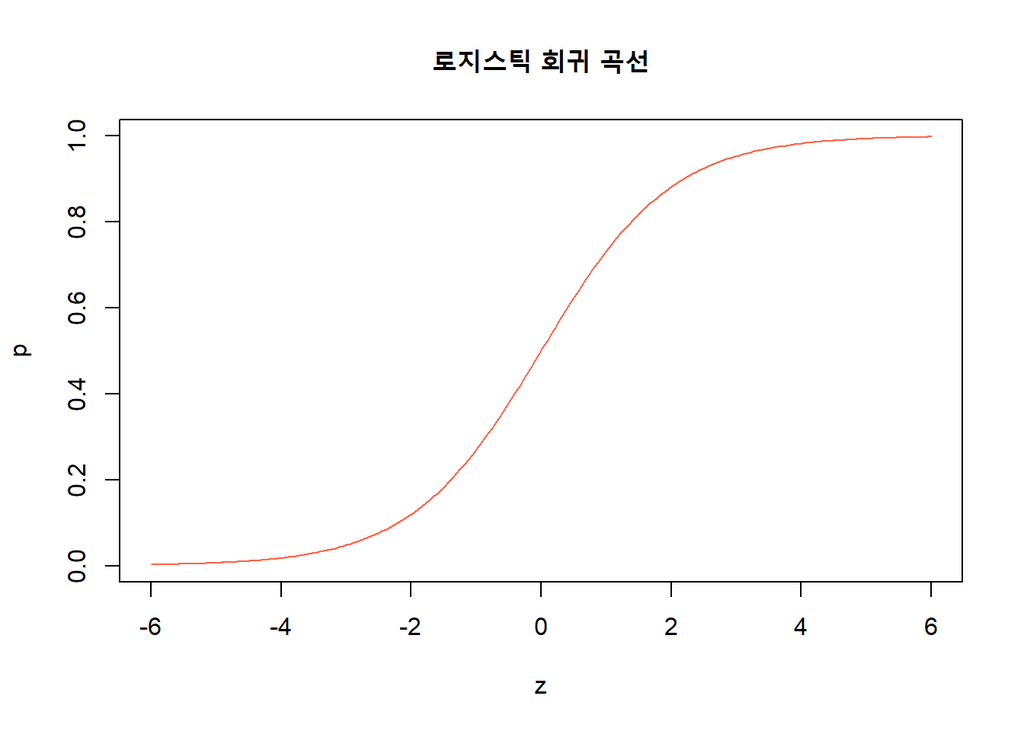

```r
e <- exp(1)
z <- seq(-6,6, length = 200)
p<- 1/(1+e^(-z))
plot(z, p, type = 'l', col = 'tomato', main = '로지스틱 회귀 곡선')
```

```r
library(MASS)
df<- na.omit(survey[,c('Sex','Height')])
df$Sex <- ifelse(df$Sex == 'Male', 1, 0)
model<- glm(Sex ~ Height, data = df, family = binomial(link = 'logit'))
model
```

```
##
## Call:  glm(formula = Sex ~ Height, family = binomial(link = "logit"),
##     data = df)
##
## Coefficients:
## (Intercept)       Height
##    -43.1119       0.2512
##
## Degrees of Freedom: 207 Total (i.e. Null);  206 Residual
## Null Deviance:       288.3
## Residual Deviance: 167   AIC: 171
```

- 오즈비 odds ratio
  - 다른 독립변수가 동일하다는 가정 하에서
  - 특정 독립변수 한 단위 증가에 따른 사건 발생확률 대 미 발생확률 비율의 변화율

```r
exp(coef(model))
```

```
##  (Intercept)       Height
## 1.891255e-19 1.285541e+00
```

#### 로지스틱 모형을 통한 예측

```r
pr <- predict(model, newdata = data.frame(list(Height = df$Height)), type = 'response')

cat(
head(df$Height, 5),'\n',
head(pr,5))
```

```
## 173 177.8 160 165 172.72
##  0.5847395 0.8246137 0.05102439 0.1588006 0.5675666
```

#### 예측 결과에 대한 혼동행렬

```r
table(df$Sex, pr>0.5 , dnn = c('real', 'Predicted'))
```

```
##     Predicted
## real FALSE TRUE
##    0    86   16
##    1    22   84
```

- 혼동행렬
  - 정확도 : Accuracy = (TP + TN)/(TP + TN + FP + FN)
  - 정밀도 : Precision = (TP)/(TP + FP)
  - 재현율 : Recall = (TP)/(TP + FN)
  - f1-Score : F1 = 2 X (Precision X Recall)/(Precision + Recall)

#### 혼동행렬에서의 ROC 곡선, AUC

- ROC : 혼동행렬에서 FP 비율과 TP 비율의 관계
- AUC : ROC 곡선의 하부 면적

```r
library(pROC)
prf <- roc(df$Sex, pr)
```

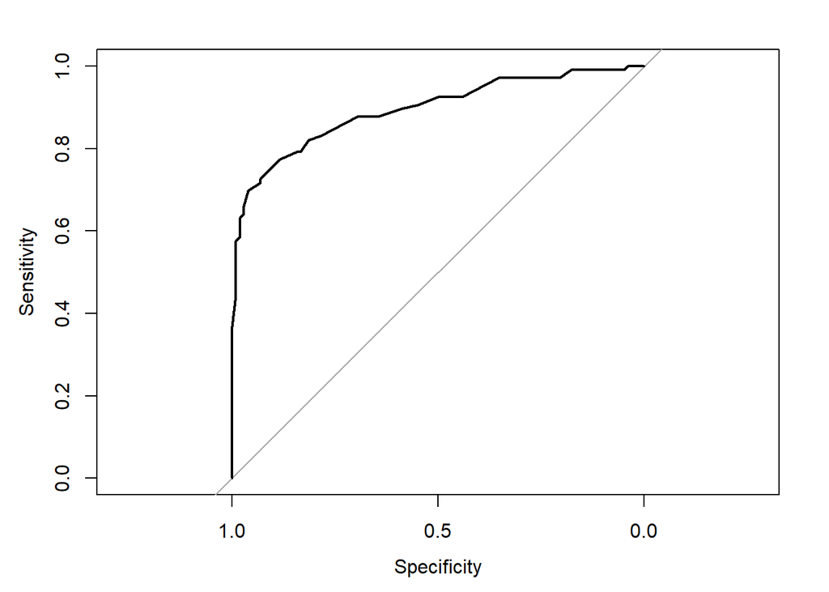

```r
plot.roc(prf)
```

```r
prf$auc
```

```
## Area under the curve: 0.8944
```

## 다항로지스틱 회귀분석

- 세 개 이상의 사건을 갖는 결과변수의 사건 발생확률 예측
- ln(p_k / 1-p) = a_k + b1_k X x1 + b2_k X x2…
- p_k = (e^z X k)/(1+ sum(e^z X i) )

```r
df<- na.omit(survey)
library(VGAM)
vglm(Smoke ~ Age+Sex, data = df , family = multinomial())
```

```
##
## Call:
## vglm(formula = Smoke ~ Age + Sex, family = multinomial(), data = df)
##
##
## Coefficients:
## (Intercept):1 (Intercept):2 (Intercept):3         Age:1         Age:2
##   -0.08404363    3.64867356    1.89590632    0.01761483   -0.02444904
##         Age:3     SexMale:1     SexMale:2     SexMale:3
##   -0.05225774   -1.61919982   -1.37161456   -1.42764934
##
## Degrees of Freedom: 504 Total; 495 Residual
## Residual deviance: 234.4889
## Log-likelihood: -117.2444
##
## This is a multinomial logit model with 4 levels
```